# Would you have survived the Titanic shipwreck?

To answer that question, we use [a dataset provided by Kaggle](https://www.kaggle.com/c/titanic/overview) about the Titanic shipwreck.

First, let's import some packages and load the dataset:

```python
import holoviews as hv
import hvplot.pandas
from hvplot import hvPlot
import numpy as np
import pandas as pd
import seaborn as sns

hv.extension("bokeh")
sns.set_style("darkgrid")
sns.set_context("poster")
```

```python
train_data = pd.read_csv("data/titanic/train.csv")
test_data = pd.read_csv('data/titanic/test.csv')
```

## Inspecting our dataset

Firstly, let's look at some randomly chosen samples in our dataset:

```python
train_data.sample(5)
```

|  | PassengerId | Survived | Pclass | Name | Sex | Age | SibSp | Parch | Ticket | Fare | Cabin | Embarked |
| --- | --- | --- | --- | --- | --- | --- | --- | --- | --- | --- | --- | --- |
| 888 | 889 | 0 | 3 | Johnston, Miss. Catherine Helen "Carrie" | female | NaN | 1 | 2 | W./C. 6607 | 23.4500 | NaN | S |
| 158 | 159 | 0 | 3 | Smiljanic, Mr. Mile | male | NaN | 0 | 0 | 315037 | 8.6625 | NaN | S |
| 795 | 796 | 0 | 2 | Otter, Mr. Richard | male | 39.0 | 0 | 0 | 28213 | 13.0000 | NaN | S |
| 556 | 557 | 1 | 1 | Duff Gordon, Lady. (Lucille Christiana Sutherl... | female | 48.0 | 1 | 0 | 11755 | 39.6000 | A16 | C |
| 515 | 516 | 0 | 1 | Walker, Mr. William Anderson | male | 47.0 | 0 | 0 | 36967 | 34.0208 | D46 | S |

To understand better, the meaning of the different features, we can look at the dataset description on Kaggle (linked above):

> | Variable | Definition | Key |
> | --- | --- | --- |
> | survival | Survival | 0 = No, 1 = Yes |
> | pclass | Ticket class | 1 = 1st, 2 = 2nd, 3 = 3rd |
> | sex | Sex |  |
> | Age | Age in years |  |
> | sibsp | # of siblings / spouses aboard the Titanic |  |
> | parch | # of parents / children aboard the Titanic |  |
> | ticket | Ticket number |  |
> | fare | Passenger fare |  |
> | cabin | Cabin number |  |
> | embarked | Port of Embarkation | C = Cherbourg, Q = Queenstown, S = Southampton |

> **Variable Notes**  
> pclass: A proxy for socio-economic status (SES)  
> 1st = Upper  
> 2nd = Middle  
> 3rd = Lower

> age: Age is fractional if less than 1. If the age is estimated, is it in the form of xx.5

> sibsp: The dataset defines family relations in this way...  
> Sibling = brother, sister, stepbrother, stepsister  
> Spouse = husband, wife (mistresses and fiancés were ignored)

> parch: The dataset defines family relations in this way...  
> Parent = mother, father  
> Child = daughter, son, stepdaughter, stepson  
> Some children travelled only with a nanny, therefore parch=0 for them.

Using the `shape` attribute, we can have see the dimensionality of our dataset:

```python
train_data.shape
```

```
(891, 12)
```

Here, our training dataset has 12 features and 891 samples.

**Now, let's use the `info` method to get the names of the columns and information about them (number of non null and type):**

```python
train_data.info()
```

```
<class 'pandas.core.frame.DataFrame'>
RangeIndex: 891 entries, 0 to 890
Data columns (total 12 columns):
 #   Column       Non-Null Count  Dtype
---  ------       --------------  -----
 0   PassengerId  891 non-null    int64
 1   Survived     891 non-null    int64
 2   Pclass       891 non-null    int64
 3   Name         891 non-null    object
 4   Sex          891 non-null    object
 5   Age          714 non-null    float64
 6   SibSp        891 non-null    int64
 7   Parch        891 non-null    int64
 8   Ticket       891 non-null    object
 9   Fare         891 non-null    float64
 10  Cabin        204 non-null    object
 11  Embarked     889 non-null    object
dtypes: float64(2), int64(5), object(5)
memory usage: 83.7+ KB
```

We see for instance that there is quite a number of samples without "Age" (we'll see how many later).

**Another useful method to inspect our dataset is `describe`: it shows how the data is distributed (on numerical features only, of course!):**

```python
train_data.describe()
```

|  | PassengerId | Survived | Pclass | Age | SibSp | Parch | Fare |
| --- | --- | --- | --- | --- | --- | --- | --- |
| count | 891.000000 | 891.000000 | 891.000000 | 714.000000 | 891.000000 | 891.000000 | 891.000000 |
| mean | 446.000000 | 0.383838 | 2.308642 | 29.699118 | 0.523008 | 0.381594 | 32.204208 |
| std | 257.353842 | 0.486592 | 0.836071 | 14.526497 | 1.102743 | 0.806057 | 49.693429 |
| min | 1.000000 | 0.000000 | 1.000000 | 0.420000 | 0.000000 | 0.000000 | 0.000000 |
| 25% | 223.500000 | 0.000000 | 2.000000 | 20.125000 | 0.000000 | 0.000000 | 7.910400 |
| 50% | 446.000000 | 0.000000 | 3.000000 | 28.000000 | 0.000000 | 0.000000 | 14.454200 |
| 75% | 668.500000 | 1.000000 | 3.000000 | 38.000000 | 1.000000 | 0.000000 | 31.000000 |
| max | 891.000000 | 1.000000 | 3.000000 | 80.000000 | 8.000000 | 6.000000 | 512.329200 |

## Cleaning our dataset

### The "Sex" column

**Firstly, we see the different values (and their count) in the "Sex" column:**

```python
train_data["Sex"].value_counts()
```

```
male      577
female    314
Name: Sex, dtype: int64
```

We can't use "male" and "female" to train our model, so we encode it as a numerical feature:

```python
train_data["SexNum"] = train_data["Sex"].map({"male": 0, "female": 1})
train_data["SexNum"].value_counts()
```

```
0    577
1    314
Name: SexNum, dtype: int64
```

We can see that "male" and "female" were successfully converted to 0 and 1 and that the value counts have not changed.

### The "Embarked" column

**Once more, we use `value_counts` to get the proportion of the different values of the "Embarked" column, this time normalizing the data at the same time:**

```python
train_data["Embarked"].value_counts(normalize=True)
```

```
S    0.724409
C    0.188976
Q    0.086614
Name: Embarked, dtype: float64
```

> **Note:** here, each letter corresponds to the first letter of the harbour at which people embarked, being either Southhampton, Cherbourg or Queenstown.

We create a new numerical feature from it, as we did with the "Sex" column:

```python
train_data["EmbarkedNum"] = train_data["Embarked"].map({"S": 1, "C": 2, "Q": 3})
```

```python
train_data["EmbarkedNum"].value_counts(normalize=True, dropna=False)
```

```
1.0    0.722783
2.0    0.188552
3.0    0.086420
NaN    0.002245
Name: EmbarkedNum, dtype: float64
```

NaN values will also not handled well by our model, so let's replace them with 0:

```python
train_data["EmbarkedNum"] = train_data["EmbarkedNum"].fillna(0)
```

### The "Age" column

**We start by plotting an histogram of the "Age" column:**

```python
train_data["Age"].hvplot.hist()
```

[interactive chart not shown]

We saw earlier that we have some observations which are missing the "Age" feature. Let's find out how many:

```python
train_data["Age"].isnull().sum()
```

```
177
```

To train our model later, we need to fill the gaps in our data. However, we can do better than with the "Embarked" column where we just replaced missing data by 0. Here, we will fill "Age" gaps by the median age depending on the passenger class (first class being the best and third the worst).

So the first step is to create a pivot table with these median ages:

```python
age_median = train_data.pivot_table("Age", index="Pclass", aggfunc="median")
age_median
```

| Pclass | Age |
| --- | --- |
| 1 | 37.0 |
| 2 | 29.0 |
| 3 | 24.0 |

That essentially tells us that people travelling in first class were older, while people in third class were younger (no big surprise here).

Now, for each observation missing "Age", we fill it with the median value corresponding to its passenger class:

```python
train_data["Age"] = train_data[["Age", "Pclass"]].apply(lambda x: age_median.loc[x["Pclass"]].values[0] if pd.isnull(x["Age"]) else x["Age"], axis=1)
```

Let's plot an histogram of our "Age" column again to see how things have changed:

```python
train_data["Age"].hvplot.hist()
```

[interactive chart not shown]

We can deduce that most observations missing values were passengers in third class.

## Creating new features

### Sociological features

So far, we have cleaned data from our existing features. Now, let's create new ones which might be useful to train our model later: we will start by combining the number of sibling/spouses and the number of parents/children on board into one new feature called "Family":

```python
train_data["Family"] = train_data["SibSp"] + train_data["Parch"]
```

```python
train_data["Family"].value_counts()
```

```
0     537
1     161
2     102
3      29
5      22
4      15
6      12
10      7
7       6
Name: Family, dtype: int64
```

```python
train_data["Family"].value_counts().sum()
```

```
891
```

We will also create a new column combining the number of members in the family and the passenger class, which we can not interpret directly but our model might:

```python
train_data["Socio"] = (train_data["Family"] + 1) * train_data["Pclass"]  # the ""+ 1" is to count oneself
```

```python
train_data["Socio"].value_counts()
```

```
3     348
2     174
1     109
6      92
9      47
4      41
18     17
8      13
21     12
15     12
12     10
33      7
24      6
5       2
10      1
Name: Socio, dtype: int64
```

### Extracting a new feature for the "Cabin" column

Let's have a look at a sample of the "Cabin" column:

```python
train_data["Cabin"].sample(15, random_state=10)
```

```
590      NaN
131      NaN
628      NaN
195      B80
230      C83
646      NaN
75     F G73
586      NaN
569      NaN
287      NaN
666      NaN
43       NaN
600      NaN
284      A19
242      NaN
Name: Cabin, dtype: object
```

We see that there is a lot of missing data. Also, if we think about it, we probably don't care about the exact cabin number; knowing the deck could be helpful though...

We can create a new "Deck" column, knowing that the deck is the first letter of the cabin:

```python
train_data["Deck"] = train_data["Cabin"].apply(lambda x: x if isinstance(x, float) else x[0])
```

```python
train_data["Deck"].value_counts()
```

```
C    59
B    47
D    33
E    32
A    15
F    13
G     4
T     1
Name: Deck, dtype: int64
```

The amount of data we have obviously didn't increase, but it's at least grouped in a more meaningful way.

Also, we see from the value counts that values "A", "F", "G" and "T" are really under-represented, so we group them in an "other" value:

```python
train_data["Deck"] = np.where(train_data["Deck"].isin(["A", "F", "G", "T"]), "other", train_data["Deck"])
train_data["Deck"].value_counts()
```

```
C        59
B        47
D        33
other    33
E        32
Name: Deck, dtype: int64
```

Now, we dummy-encode our categorical values to get numerical values which can later be used by our model:

```python
deck_dummies = pd.get_dummies(train_data["Deck"], prefix="Deck")
```

```python
deck_dummies.head()
```

|  | Deck_B | Deck_C | Deck_D | Deck_E | Deck_other |
| --- | --- | --- | --- | --- | --- |
| 0 | 0 | 0 | 0 | 0 | 0 |
| 1 | 0 | 1 | 0 | 0 | 0 |
| 2 | 0 | 0 | 0 | 0 | 0 |
| 3 | 0 | 1 | 0 | 0 | 0 |
| 4 | 0 | 0 | 0 | 0 | 0 |

We concatenate these new columns with our existing dataset:

```python
train_data = pd.concat([train_data, deck_dummies], axis=1)
train_data.shape
```

```
(891, 22)
```

We started with 12 features, we now have 22. It's time to drop the columns that we won't need (the name of the passengers for instance, or their gender as it has been encoded):

```python
to_drop = ["Name", "Ticket", "Cabin", "Sex", "Embarked", "Deck"]
train_data.drop(to_drop, axis=1, inplace=True)
```

Finally, we reorder the columns of our dataframe to have the target (what our model has to predict) in the right-most column:

```python
col = train_data.columns.tolist()
col.append(col.pop(col.index("Survived")))

train_data = train_data[col]
train_data.sample(5)
```

|  | PassengerId | Pclass | Age | SibSp | Parch | Fare | SexNum | EmbarkedNum | Family | Socio | Deck_B | Deck_C | Deck_D | Deck_E | Deck_other | Survived |
| --- | --- | --- | --- | --- | --- | --- | --- | --- | --- | --- | --- | --- | --- | --- | --- | --- |
| 268 | 269 | 1 | 58.0 | 0 | 1 | 153.4625 | 1 | 1.0 | 1 | 2 | 0 | 1 | 0 | 0 | 0 | 1 |
| 391 | 392 | 3 | 21.0 | 0 | 0 | 7.7958 | 0 | 1.0 | 0 | 3 | 0 | 0 | 0 | 0 | 0 | 1 |
| 758 | 759 | 3 | 34.0 | 0 | 0 | 8.0500 | 0 | 1.0 | 0 | 3 | 0 | 0 | 0 | 0 | 0 | 0 |
| 51 | 52 | 3 | 21.0 | 0 | 0 | 7.8000 | 0 | 1.0 | 0 | 3 | 0 | 0 | 0 | 0 | 0 | 0 |
| 234 | 235 | 2 | 24.0 | 0 | 0 | 10.5000 | 0 | 1.0 | 0 | 2 | 0 | 0 | 0 | 0 | 0 | 0 |

This is how our dataset looks after after cleaning it up, adding new features and removing useless ones.

To finish, we can visualize the correlation between our different features:

```python
train_data.corr().hvplot.heatmap(cmap="RdYlGn", height=580, width=700)
```

[interactive chart not shown]

Before we can begin the machine learning part, let's quickly apply all these transformations to our test dataset, and save both dataframes in new CSV files:

```python
test_data["SexNum"] = test_data["Sex"].map({"male": 0, "female": 1})

test_data["EmbarkedNum"] = test_data["Embarked"].map({"S": 1, "C": 2, "Q": 3})
test_data["EmbarkedNum"] = test_data["EmbarkedNum"].fillna(0)

test_data["Age"] = test_data[["Age", "Pclass"]].apply(lambda x: age_median.loc[x["Pclass"]].values[0] if pd.isnull(x["Age"]) else x["Age"], axis=1)

test_data["Family"] = test_data["SibSp"] + test_data["Parch"]

test_data["Socio"] = (test_data["Family"] + 1) * test_data["Pclass"]

test_data["Deck"] = test_data["Cabin"].apply(lambda x: x if isinstance(x, float) else x[0])
test_data["Deck"] = np.where(test_data["Deck"].isin(["A", "F", "G", "T"]), "other", test_data["Deck"])
deck_dummies = pd.get_dummies(test_data["Deck"], prefix="Deck")
test_data = pd.concat([test_data, deck_dummies], axis=1)

to_drop = ["Name", "Ticket", "Cabin", "Sex", "Embarked", "Deck"]
test_data.drop(to_drop, axis=1, inplace=True)
```

```python
train_data.to_csv("./data/train_clean.csv")
test_data.to_csv("./data/test_clean.csv")
```

## Training models

We first start by splitting the data in features and target:

```python
X = train_data.iloc[:, :-1]
y = train_data.iloc[:, -1]
```

Before training any model, let's just have a closer look at the data to understand roughly how it is distributed.

Let's for instance see the number of passengers who survived based on the gender:

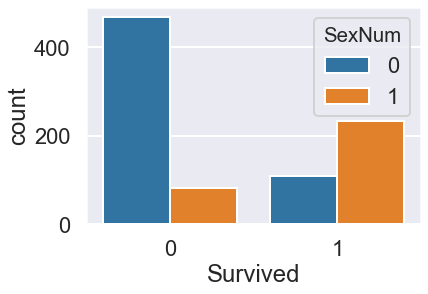

```python
sns.countplot(x="Survived", hue="SexNum", data=train_data);
```

As we can see:

1. there were less women than men on the ship
2. more women survived the shipwreck

Let's now visualize the survival rate based on the passenger class:

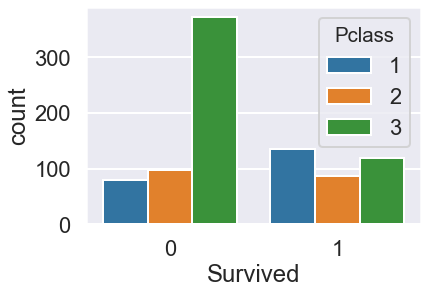

```python
sns.countplot(x="Survived", hue="Pclass", data=train_data);
```

### Splitting the data into training, validation and testing sets

The variable `test_data` holds the final data on which we'll make predictions that will be submitted to Kaggle. In order to train our model locally and see how well it performs without having to upload predictions to Kaggle, we'll split our `train_data` once more into a training and a validation sets:

```python
from sklearn.model_selection import train_test_split
X_train, X_test, y_train, y_test = train_test_split(X, y, test_size=0.3, stratify=y, random_state=42)
```

The value of `test_size` corresponds to the percentage of data we keep for testing out of all our data (here 30%).

### Creating our baseline models

Before training any complex models, we usually want to see how well very simple ones perform, to get a baseline we want to beat.

First, we create a dummy classifier (as our task is classification, *i.e.* saying whether someone is in the category of survivors or not) which will make random prediction:

```python
from sklearn.dummy import DummyClassifier
dummy_cl_str = DummyClassifier(random_state=42, strategy="stratified")
```

We *fit* the dummy classifier to the training data:

```python
dummy_cl_str.fit(X_train, y_train)
```

```
DummyClassifier(constant=None, random_state=42, strategy='stratified')
```

Let's look at the predictions our dummy classifier do on the test data:

```python
y_pred_dummy_cl_str = dummy_cl_str.predict(X_test)
y_pred_dummy_cl_str
```

```
array([0, 1, 1, 0, 0, 0, 0, 1, 0, 1, 0, 1, 1, 0, 0, 0, 0, 0, 0, 0, 0, 0,
       0, 0, 0, 1, 0, 0, 0, 0, 0, 0, 0, 1, 1, 1, 0, 0, 1, 0, 0, 0, 0, 1,
       0, 1, 0, 0, 0, 0, 1, 1, 1, 1, 0, 1, 0, 0, 0, 0, 0, 0, 1, 0, 0, 0,
       0, 1, 0, 1, 1, 0, 0, 1, 1, 1, 1, 0, 0, 0, 1, 1, 0, 0, 0, 0, 1, 1,
       1, 0, 0, 1, 1, 0, 1, 0, 0, 0, 0, 0, 0, 1, 0, 0, 1, 0, 0, 1, 0, 0,
       0, 0, 1, 1, 1, 1, 1, 0, 1, 0, 1, 1, 0, 0, 0, 0, 1, 1, 0, 0, 0, 0,
       0, 0, 1, 0, 0, 1, 0, 1, 1, 0, 0, 0, 0, 0, 0, 0, 0, 0, 1, 0, 0, 0,
       1, 0, 1, 1, 0, 1, 0, 1, 1, 0, 0, 1, 0, 0, 0, 0, 1, 0, 0, 0, 1, 0,
       1, 0, 1, 0, 0, 0, 1, 1, 0, 1, 1, 0, 0, 0, 0, 1, 1, 1, 0, 0, 1, 1,
       1, 1, 1, 0, 0, 1, 0, 0, 0, 1, 0, 0, 0, 1, 1, 0, 1, 0, 0, 1, 1, 1,
       1, 0, 0, 0, 0, 0, 1, 0, 1, 1, 1, 0, 0, 0, 0, 1, 0, 0, 1, 0, 1, 1,
       1, 0, 0, 1, 0, 1, 1, 1, 0, 0, 1, 0, 0, 0, 1, 1, 0, 0, 0, 1, 0, 0,
       1, 1, 1, 1])
```

We see that the predictions contain both 0 and 1 (for dead or survivor, respectively).

We can also get the accuracy score of our model:

```python
dummy_cl_str.score(X_test, y_test)
```

```
0.5298507462686567
```

Our model has around 50% accuracy, which is not surprising as it is randomly prediction survival rate.

Now, we'll change our dummy classifier's strategy to be "most frequent", meaning that it will always output the most frequent value in the training dataset. As before, let's train it and see the predictions it makes on our test data:

```python
dummy_cl_mf = DummyClassifier(strategy="most_frequent", random_state=42)
dummy_cl_mf.fit(X_train, y_train)
y_pred_dummy_cl_mf = dummy_cl_mf.predict(X_test)
y_pred_dummy_cl_mf
```

```
array([0, 0, 0, 0, 0, 0, 0, 0, 0, 0, 0, 0, 0, 0, 0, 0, 0, 0, 0, 0, 0, 0,
       0, 0, 0, 0, 0, 0, 0, 0, 0, 0, 0, 0, 0, 0, 0, 0, 0, 0, 0, 0, 0, 0,
       0, 0, 0, 0, 0, 0, 0, 0, 0, 0, 0, 0, 0, 0, 0, 0, 0, 0, 0, 0, 0, 0,
       0, 0, 0, 0, 0, 0, 0, 0, 0, 0, 0, 0, 0, 0, 0, 0, 0, 0, 0, 0, 0, 0,
       0, 0, 0, 0, 0, 0, 0, 0, 0, 0, 0, 0, 0, 0, 0, 0, 0, 0, 0, 0, 0, 0,
       0, 0, 0, 0, 0, 0, 0, 0, 0, 0, 0, 0, 0, 0, 0, 0, 0, 0, 0, 0, 0, 0,
       0, 0, 0, 0, 0, 0, 0, 0, 0, 0, 0, 0, 0, 0, 0, 0, 0, 0, 0, 0, 0, 0,
       0, 0, 0, 0, 0, 0, 0, 0, 0, 0, 0, 0, 0, 0, 0, 0, 0, 0, 0, 0, 0, 0,
       0, 0, 0, 0, 0, 0, 0, 0, 0, 0, 0, 0, 0, 0, 0, 0, 0, 0, 0, 0, 0, 0,
       0, 0, 0, 0, 0, 0, 0, 0, 0, 0, 0, 0, 0, 0, 0, 0, 0, 0, 0, 0, 0, 0,
       0, 0, 0, 0, 0, 0, 0, 0, 0, 0, 0, 0, 0, 0, 0, 0, 0, 0, 0, 0, 0, 0,
       0, 0, 0, 0, 0, 0, 0, 0, 0, 0, 0, 0, 0, 0, 0, 0, 0, 0, 0, 0, 0, 0,
       0, 0, 0, 0])
```

Now, we see that our model always predicts 0 (*i.e.* the person died), regardless of the different passenger characteristics.

Let's see which score this model gets:

```python
dummy_cl_mf.score(X_test, y_test)
```

```
0.6156716417910447
```

We see that this model does much better than the previous one. If you think about it, it makes sense as there are more people who died than survived in the shipwreck.

To make sure that this accuracy is not a statistical fluke, let's use cross validation. We'll split our dataset into $k$ equal parts and use $k - 1$ parts to train our model and 1 part to test it and repeat that process $k$ times. Here we do a 5-fold cross validation:

```python
from sklearn.model_selection import cross_val_score

scores_dummy_mf = cross_val_score(dummy_cl_mf, X, y, cv=5)
print(f"Scores: {scores_dummy_mf}")
print(f"Mean: {scores_dummy_mf.mean()}")
```

```
Scores: [0.61452514 0.61797753 0.61797753 0.61797753 0.61235955]
Mean: 0.6161634548992531
```

We see that whatever split we do, we always get a similar score, so we'll our dummy classifier with the "most frequent" strategy as baseline.

To conclude, one can notice that the accuracy we get actually corresponds to the percentage of people who died:

```python
train_data["Survived"].value_counts(normalize=True)
```

```
0    0.616162
1    0.383838
Name: Survived, dtype: float64
```

### Doing better than the baseline

#### Creating a random forest classifier

Our aim will now be to get a model which performs better than our baseline. We'll use a random forest classifier for this, as these models perform very well on this type of tasks.

As earlier, let's create the model, train it and look at its predictions and score:

```python
from sklearn.ensemble import RandomForestClassifier

rf_cl = RandomForestClassifier()
rf_cl.fit(X_train, y_train);
y_pred_rf_cl = rf_cl.predict(X_test)
print(f"Predictions:\n{y_pred_rf_cl}")
print(f"Score: {rf_cl.score(X_test, y_test)}")
```

```
Predictions:
[1 0 0 0 0 1 0 1 0 1 1 1 0 0 1 1 0 1 1 1 0 0 0 0 1 0 1 0 0 0 1 1 0 1 1 0 0
 0 0 0 0 1 0 1 1 0 0 0 0 0 0 0 0 1 0 0 1 0 0 0 0 0 0 1 0 0 0 1 0 0 1 1 0 1
 0 0 0 0 0 0 0 1 1 0 0 0 0 1 0 0 1 0 0 1 0 1 1 1 0 0 0 1 1 1 0 0 1 0 0 0 0
 0 0 0 0 0 1 0 1 1 0 1 1 0 1 1 0 0 1 0 0 0 1 0 1 1 0 1 0 1 0 1 0 0 1 0 1 1
 0 0 0 0 1 0 0 0 0 1 0 0 0 0 1 0 0 1 0 0 1 1 0 1 0 0 1 0 0 0 0 1 0 1 0 0 0
 1 0 0 1 0 0 1 1 1 0 0 1 0 1 1 1 1 0 0 1 0 1 1 0 0 1 0 1 1 0 0 0 1 0 0 0 0
 0 0 1 1 0 0 1 0 0 0 0 0 1 1 0 0 0 0 0 0 0 0 0 0 1 0 0 0 1 1 0 0 1 1 1 1 0
 0 0 0 0 1 0 0 0 1]
Score: 0.7910447761194029
```

We see that even with the default parameters, our random forest performs much better than our baseline.

Let's use cross validation once more to check that this higher score was not a coincidence:

```python
scores_rf_cl = cross_val_score(rf_cl, X, y, cv=5)
print(f"Scores: {scores_rf_cl}")
print(f"Mean: {scores_rf_cl.mean()}")
```

```
Scores: [0.7150838  0.79775281 0.88202247 0.82022472 0.83707865]
Mean: 0.8104324901136151
```

We see that, although the model performed better or worse for each fold, our initial model was very close to the average score.

#### Parameter Tuning

The model that we trained now used default parameters, so let's try to tune the different parameters to get a better model. We'll use `GridSearchCV` to automate the testing of different parameters combinations:

```python
from sklearn.model_selection import GridSearchCV

param = {
    "max_depth": [5, 3, 1, None],
    "n_estimators": [3, 10, 30, 100, 300, 500],
    "max_features": [2, 4, 6, 8, 10],
}

# Create the GridSearch with the above parameters and fit it
grid_search = GridSearchCV(rf_cl, param, cv=5, scoring="accuracy")
grid_search.fit(X, y);
```

Let's see what are the best parameters found by the GridSearch:

```python
grid_search.best_params_
```

```
{'max_depth': 5, 'max_features': 6, 'n_estimators': 300}
```

```python
model = RandomForestClassifier(**grid_search.best_params_)
model.fit(X_train, y_train)
y_pred = model.predict(X_test)
scores_model = cross_val_score(model, X, y, cv=5)
print(f"Mean: {scores_rf_cl.mean()}")
```

```
Mean: 0.8104324901136151
```

#### Interpreting the results

Let's see what different visual representations of our data we can make.

First we'll start with a scatterplot of our prediction compared to the ground truth:

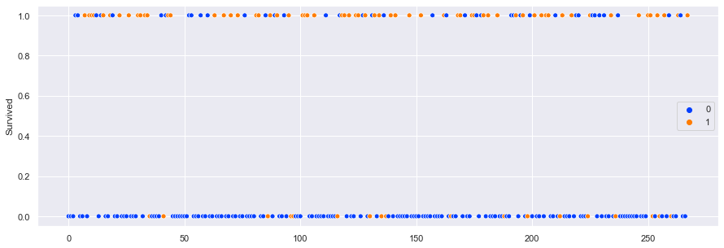

```python
sns.set(rc={"figure.figsize": (15, 5)})
sns.scatterplot(range(len(y_test)), y_test, hue=y_pred, palette="bright");
```

Here, the orange dots in the bottom line and the blue dots in the top line correspond to prediction errors.

The number of dots make it difficult to draw a conclusion, so let's now look at the confusion matrix to understand better how our model performs. A confusion matrix is matrix representing the following:

|  | Prediction True | Prediction False |
| --- | --- | --- |
| **Actual True** | True Positive | False Negative |
| **Actual False** | False Positive | True Negative |

It is a particularly helpful representation for binary classification tasks, like our.

Let's calculate it first and then plot it:

```
[[147  18]
 [ 39  64]]
```

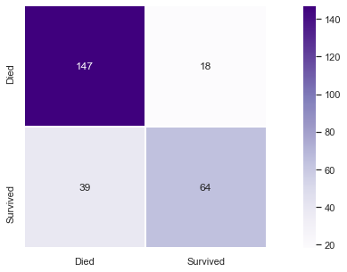

```python
from sklearn.metrics import confusion_matrix
cm = confusion_matrix(y_test, y_pred)
print(cm)

labels = ["Died", "Survived"]
sns.heatmap(
    cm,
    annot=True,
    fmt="d",
    xticklabels=labels,
    yticklabels=labels,
    square=True,
    linewidths=1,
    cmap="Purples"
);
```

From this plot, we see that our model predicted too many dead people in general, which we can verify by looking at the value counts:

```python
pd.Series(y_pred).value_counts(normalize=True)
```

```
0    0.69403
1    0.30597
dtype: float64
```

Finally, the last useful visualization we can use for binary classification is the ROC curve (Receiver Operating Characteristic). It represents the rate of True Positives vs False Positives.

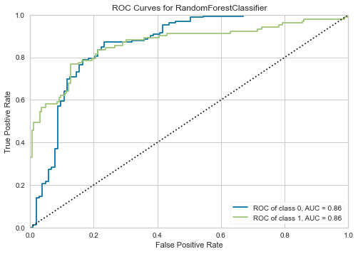

```python
from yellowbrick import ROCAUC

auc = ROCAUC(model, micro=False, macro=False)
auc.fit(X_train, y_train)
auc.score(X_test, y_test)
auc.poof();
```

On this plot, we can see that:

- at (0, 1) we have a perfect model, with only true positives and no false positives
- at (1, 0), we have the opposite: the worst model, with only false positives. It can be simply reversed to get a perfect model
- the black beeline shows what a random model would do

## Conclusion

Throughout this tutorial, we have seen how to:

- read a dataset into a *pandas*' dataframe and inspect its content
- fill gaps in certain features, how to create new features (feature engineering) and how to drop features
- split our dataset to train models and avoid overfitting
- find a good baseline model
- find a model better than the baseline
- visualize the results

Of course, although the model we got at the end achieves scores higher than our baseline by 20 points, we could get even better results by using different types of models but that's out of the scope of this tutorial!